# **Parte 1.** Preparación y modelado de los datos

Datos no estructurados

2022-05-18

`Equipo #3`

- Carolina Velarde Díaz A01720509
- Chantal Aimeé Simó García A00827554
- Ximena Araceli Martínez Flores A00829670
- Kízari Hernández Huerta A00828451

## 0.1 **Antecedentes**

Fundada en 1982 por un pequeño grupo de emprendedores, Softtek comenzó en México proporcionando servicios de TI locales y hoy es un líder global en soluciones digitales de próxima generación. La primera compañía en introducir el modelo *Nearshore*, Softtek ayuda a las empresas Global 2000 a desarrollar capacidades digitales de manera fluida y constante, desde la ideación y construcción hasta la ejecución y su evolución. Su impulso emprendedor la ha llevado a operar en más de 20 países y contar con más de 15,000 profesionales.

Actualmente Softtek es la empresa privada de tecnologías de información más grande de México y de América Latina.

## 0.2 **Descripción de la situación problema**

La industria de servicios financieros con frecuencia son blancos de diversas formas de delitos financieros y fraudes. Los escenarios han cambiado con el paso del tiempo y los actores maliciosos han amoldado sus tácticas para adaptarse mejor al mundo digital.

Es por ello que estas soluciones estarán enfocadas en el sector financiero, específicamente en instituciones financieras que requieran transformación en *FinTech* y *Customer Experience Banking Solutions*.

Nuestras propuestas buscan mejorar la experiencia del usuario dentro del sector financiero al ofrecer servicios más seguros, confiables y personalizados que los beneficiará y diferenciará con valor agregado.

## 0.3 **Spam or Ham Detection System**

**Identificación de usuarios vulnerables en casos de estafas tecnológicas**

- Casi el 85% de todos los correos electrónicos son spam *(Cveticanin, 2022)*.
- Las estafas y el fraude son solo el 2.5 % de todos los correos de spam; sin embargo, las estadísticas de phishing indican que el robo de identidad representa el 73% de esta cifra *(Cveticanin, 2022)*.
- Los americanos admiten haber perdido más de $ 70,000 USD en estafas del príncipe nigeriano (o 419) en 2019 *(Cveticanin, 2022)*.

Con el uso del Procesamiento de Lenguaje Natural (PLN) se identificará como varía el lenguaje usado en ambos medios de comunicación, para, así, poder detectar cuando un mensaje es Spam o Ham. Este sistema será incorporado en una plataforma utilizando API’s donde se pueda ingresar el correo o sms y este mismo detecte con un porcentaje de precisión si es Spam o Ham.

### 0.3.1 Valor agregado de nuestra propuesta

**Personalización**: Servicio 100% personalizado para los clientes.

**Precisión**: Detección y prevención de cibercrímenes para los usuarios.

**Versátil**: Adaptable a diferentes áreas dentro del banco.

**Confianza**: Mejorar la imagen del cliente en cuanto a la protección de sus clientes.

## 0.4 **Datos y metodología**

Las bases de datos a utilizar son:

1. **SMS**: Es un conjunto de 5,559 mensajes SMS en inglés, etiquetados según sean *Ham* (legítimos) o *Spam* (kaggle, 2022).
2. **E-mail**: Es un conjunto de 11,928 correos en inglés, etiquetados según sean *Ham* (legítimos) o *Spam* (kaggle, 2022).

## 0.5 **Análisis exploratorio**

Para facilidad de manipulación, se tomó la decisión de homologar las bases de datos en una sola, misma que contiene las siguientes variables:

- Class: Clasificación del mensaje, ya sea *Spam* o *Ham*.
- Text: Mensaje en bruto.
- Type: Tipo del mensaje, ya sea *E-mail* o *SMS*.

### 0.5.1 Visualización inicial

Para iniciar, se puede observar que contamos con las 3 variables explicadas con anterioridad, siendo los siguientes sus respectivos tipos de datos.

```r
glimpse(mensajes)
```

```
## Rows: 17,487
## Columns: 3
## $ Class <fct> Ham, Ham, Ham, Ham, Ham, Ham, Ham, Ham, Ham, Ham, Ham, Ham, Ham,…
## $ Text  <chr> "over. SidLet me know. Thx.", "Not a surprising assessment from …
## $ Type  <fct> E-mail, E-mail, E-mail, E-mail, E-mail, E-mail, E-mail, E-mail, …
```

En continuidad, es importante mencionar que la base de datos a analizar, no cuenta con ningún NA o valor perdido.

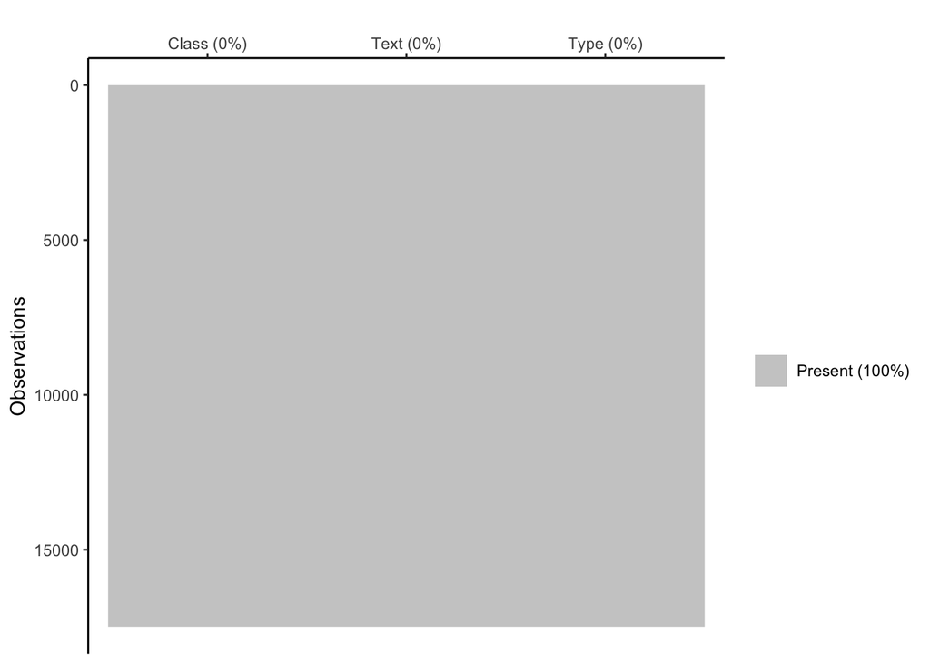

**Gráfico 1.** Datos faltantes.

Ahora, se puede visualizar que de la base de datos, 66.07% son mensajes clasificados como *Ham* y 33.93% son mensajes clasificados como *Spam*.

```r
mensajes %>% count(Class,sort = T) %>% mutate(frecuencia = percent( n /sum(n),accuracy = 0.01))
```

```
##   Class     n frecuencia
## 1   Ham 11554     66.07%
## 2  Spam  5933     33.93%
```

Por motivos de ejemplifiación, estos son los primeros 6 mensajes de la base de datos.

```r
head(mensajes$Text)
```

```
## [1] "over. SidLet me know. Thx."
## [2] "Not a surprising assessment from Embassy."
## [3] "Monica -Huma Abedin <Huma@clintonemail.com>Tuesday June 29 2010 6:01 AM'hanleymr@state.gov'; HRe:is already is locked for tonite. I am seeing her right before actually."
## [4] "Pis print.H <hrod17@clintonemail.com>Thursday October 8 2009 8:01 PM'JilotyLC@state.gov'Fw: WHI - powder coatingB6"
## [5] "Dear Tom--H <hrod17@clintonemail.com>Friday December 11 2009 5:41 PMCould we schedule a call?I have several matters I'd like to discuss w you this weekend and was hoping we can schedule a call. I'm free tonightafter 10; tomorrow btw 8-10am and Sunday btw 8-ham and after 10pm. Do any of those…
## [6] "FYI. Thanks again for signing the book ---- and I do hope you get royalties from Mongolia! Also thought you would like tosee the attached letter to President Clinton."
```

Y, como se puede observar, 68.21% son correos y 31.79% son mensajes de SMS.

```r
mensajes %>% count(Type,sort = T) %>% mutate(frecuencia = percent( n /sum(n),accuracy = 0.01))
```

```
##     Type     n frecuencia
## 1 E-mail 11928     68.21%
## 2    SMS  5559     31.79%
```

A continuación, se puede evidenciar que existen 2,102 valores duplicados en la base de datos. Estos procederán a ser eliminados de la misma.

```r
sum(duplicated(mensajes))
```

```
## [1] 2102
```

```r
mensajes <- distinct(mensajes)
```

Con las configuraciones anteriores, ahora, en total se cuenta con 10,409 mensajes clasificados como *Ham* y 4,976 mensajes clasificados como *Spam*.

De igual manera, se procederá a asignar un ID a cada mensaje.

```r
mensajes  %<>% mutate(ID = row_number())
mensajes %>% count(Type,Class,sort = T) %>% mutate(frecuencia = percent( n /sum(n),accuracy = 0.01))
```

```
##     Type Class    n frecuencia
## 1 E-mail   Ham 5906     38.39%
## 2    SMS   Ham 4503     29.27%
## 3 E-mail  Spam 4334     28.17%
## 4    SMS  Spam  642      4.17%
```

### 0.5.2 Estructura *Tidy*

Con motivos de realizar un análisis de mejor calidad, se convertirá la base de datos en formato *tidy*, con tokenización por palabra.

Esto quiere decir que como cada columna es una variable y cada fila es una observación, cada celda es un valor, o sea, la intersección entre una fila y una columna, o entre variable y observación.

Ahora, se hará una lista de todos los símbolos, palabras en otros idiomas y caracteres especiales causados por el formato .html de los correos electrónicos, para poder excluirlos del análisis.

```r
para_filtrar <- list("2e","2c","=","nbsp","br","div","äî","3e","e9","3d","ôøω","2ci","3a","2ei",
                     "td","ä","c","f","http","a","son","vous","href","d","href","b","g","de",".","wjhl",
                     ",","!","e",",,.","m","la","le","je","tu","son","avez","vous","sont",".m","cote",
                     "ci","ei","p","st","cs","da","po","ts","bt","nd","ts","st","k","cs","oso","yo",".p")
```

De manera similar, se eliminarán las palabras vacías o *stop words*, así como los números y cualquier valor nulo o “” que resulte de este procedimiento.

Y para evitar confusiones, se hará uso de la raíz de las palabras.

```r
mensajes_no_token <- mensajes
mensajes %<>% unnest_tokens(word,Text) %>%
  anti_join(stop_words)

mensajes$word <- removeNumbers(mensajes$word)
mensajes %<>% filter(!is.na(word)) %>% filter(!word == "") %>%
  dplyr::filter(!word %in% para_filtrar) %>%
  mutate(stem = wordStem(word))
mensajes$word <- str_replace_all(mensajes$word,"_","")
mensajes_email <- mensajes %>% dplyr::filter(Type == "E-mail")
mensajes_sms <- mensajes  %>% dplyr::filter(Type == "SMS")
```

### 0.5.3 Frecuencia de palabras

#### 0.5.3.1 SMS

Como se puede observar, estas son las 5 palabras más frecuentes en SMS, tanto para *Ham* como *Spam*

```r
top5smsS <- mensajes_sms %>% filter(Class == "Spam") %>% count(word,Class,sort = T) %>% head(5)
top5smsH <- mensajes_sms %>% filter(Class == "Ham") %>% count(word,Class,sort = T) %>% head(5)
rbind(top5smsS,top5smsH)
```

```
##    word Class   n
## 1  call  Spam 305
## 2  text  Spam 244
## 3  free  Spam 190
## 4  your  Spam 119
## 5  stop  Spam 113
## 6  your   Ham 202
## 7  time   Ham 189
## 8  call   Ham 186
## 9   day   Ham 182
## 10 love   Ham 175
```

```r
rm(top5smsS,top5smsH)
```

Como siguiente punto, se puede visualizar la comparativa entre palabras más usadas para cada clasificación.

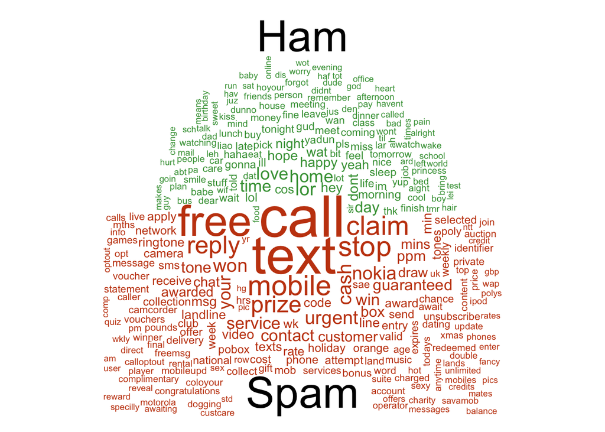

**Gráfico 2.** Nube de palabras de mensajes SMS clasificados como *Ham* y *Spam*.

#### 0.5.3.2 E-mail

Similar al proceso anterior, estas son las 5 palabras más frecuentes en mensajes de correo, tanto para *Ham* como *Spam*

```r
top5eS <- mensajes_email %>% filter(Class == "Spam") %>% count(word,Class,sort = T) %>% head(5)
top5eH <- mensajes_email %>% filter(Class == "Ham") %>% count(word,Class,sort = T) %>% head(5)
rbind(top5eS,top5eH)
```

```
##         word Class    n
## 1      money  Spam 9586
## 2       bank  Spam 7522
## 3    account  Spam 7349
## 4   business  Spam 4368
## 5       fund  Spam 4215
## 6         pm   Ham 1786
## 7     office   Ham 1008
## 8       call   Ham  909
## 9       time   Ham  849
## 10 president   Ham  810
```

```r
rm(top5eS,top5eH)
```

Como siguiente punto, se puede visualizar la comparativa entre palabras más usadas para cada clasificación.

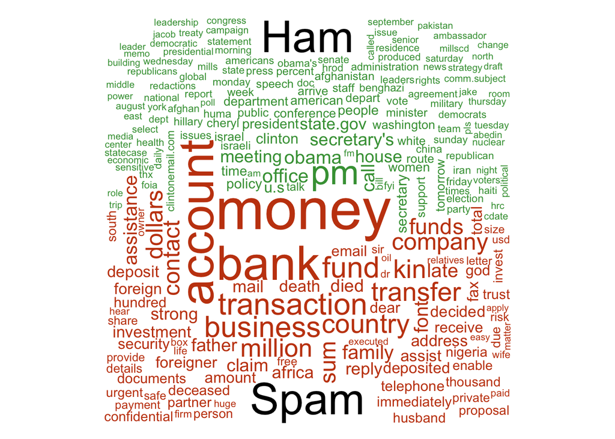

**Gráfico 3.** Nube de palabras de correos clasificados como *Ham* y *Spam*.

### 0.5.4 Importancia de palabras

```r
palabras_type <- mensajes %>%  count(word,Class,Type,sort = T) %>% ungroup()
palabras_totales <-palabras_type %>%group_by(Class) %>% summarise(total = sum(n))
mensajes_zipf <- left_join(palabras_type,palabras_totales)

rm(palabras_totales,palabras_type)

mensajes_zipf %<>%
  mutate(rank = row_number(),
         frecuencia  = (n/total),
   total = as.factor(total))
```

La ley de Zipf establece que la frecuencia de aparición de una palabra es inversamente proporcional a su rango (Robinson & Silge, 2017).

```r
set.seed(123123)
cat("Email")
```

```
## Email
```

```r
lm(log10(frecuencia) ~ log10(rank), data = mensajes_email_zipf)
```

```
##
## Call:
## lm(formula = log10(frecuencia) ~ log10(rank), data = mensajes_email_zipf)
##
## Coefficients:
## (Intercept)  log10(rank)
##     -0.7105      -1.0038
```

```r
cat("SMS")
```

```
## SMS
```

```r
lm(log10(frecuencia) ~ log10(rank), data = mensajes_sms_zipf)
```

```
##
## Call:
## lm(formula = log10(frecuencia) ~ log10(rank), data = mensajes_sms_zipf)
##
## Coefficients:
## (Intercept)  log10(rank)
##     -0.5523      -1.0069
```

Obsérvese que el *Gráfico 4* está en coordenadas logarítmicas. Se puede visualizar que las palabras clasificadas como *Ham* y/o *Spam* de SMS y correos son similares entre sí, y que la relación entre el rango y la frecuencia tiene una pendiente negativa. Sin embargo, no es del todo constante.

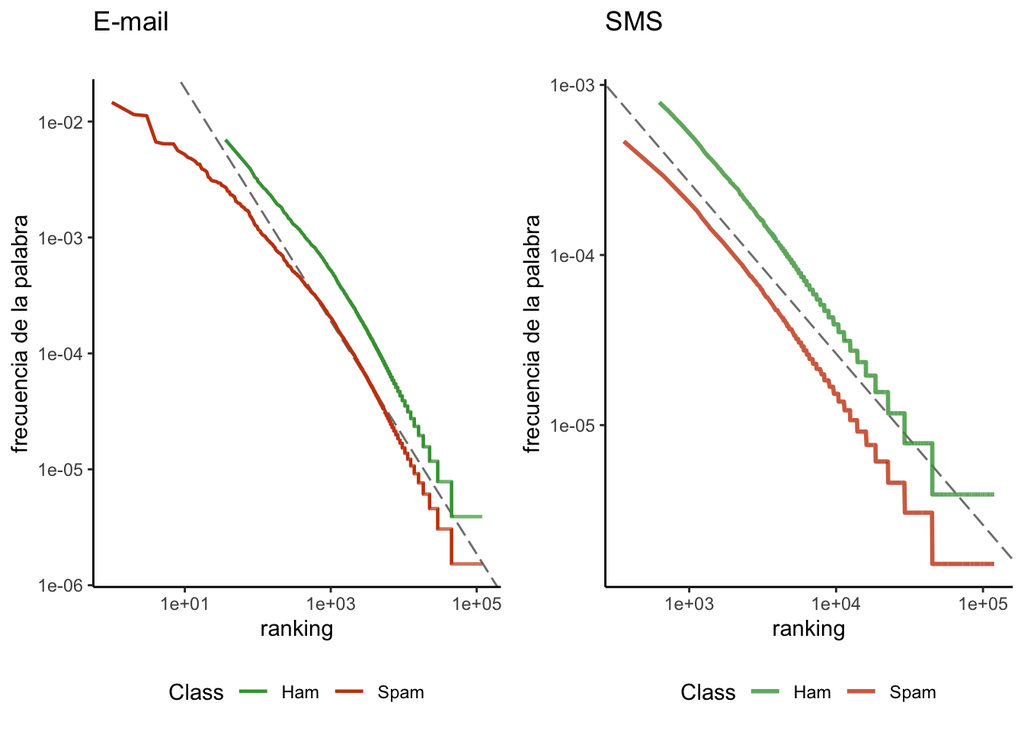

**Gráfico 4.** Relación entre frecuencia y ranking de las palabras.

## 0.6 **Análisis de sentimientos**

Antes de continuar, es de gran relevancia destacar que el análisis de sentimientos es el proceso de analizar líneas de texto con el fin de determinar el tono emocional que llevan.

En este caso, se hará uso de 2 léxicos de sentimientos, los cuales son:

- El primero, *Bing*, evalúa de manera binaria si una palabra es positiva o negativa.
- El segundo, *NRC*, evalúa a cual de los 8 sentimientos (negativo, positivo, tristeza, ira, confianza, miedo, anticipación, alegría, asco, sorpresa) pertenece la palabra.

```r
NRC <- get_sentiments("nrc")  # 8 sentimientos
BING <- get_sentiments("bing") # binario -/+
```

Después de cargar los léxicos, sólo se congregó el puntaje con la palabra.

```r
mensajes_email  %<>% inner_join(NRC) %>% mutate(nrc = as.factor(sentiment)) %>% select(-sentiment)
mensajes_email  %<>% inner_join(BING) %>% mutate(bing = as.factor(sentiment)) %>% select(-sentiment)
mensajes_sms  %<>% inner_join(NRC) %>% mutate(nrc = as.factor(sentiment)) %>% select(-sentiment)
mensajes_sms  %<>% inner_join(BING) %>% mutate(bing = as.factor(sentiment)) %>% select(-sentiment)
```

### 0.6.1 SMS

#### 0.6.1.1 NRC

Como se puede evidenciar, el sentimiento más frecuente en los mensajes clasificados como *Ham* son positivismo, negativismo y alegría. Mientras que para mensajes clasificados como *Spam* los sentimientos más frecuentes son positivismo, anticipación y sorpresa.

```r
nrc_sms_ham<- mensajes_sms %>%filter(Class == "Ham") %>% count(nrc,sort = T) %>%
  mutate(Ham = n) %>% select(-n) %>% arrange(desc(Ham)) %>%
  mutate(frecuencia = percent( Ham /sum(Ham),accuracy = 0.01))
nrc_sms_spam <- mensajes_sms %>%filter(Class == "Spam") %>% count(nrc,sort = T) %>%
  mutate(Spam = n)%>% select(-n)%>% arrange(desc(Spam)) %>%
  mutate(frecuencia = percent( Spam /sum(Spam),accuracy = 0.01))
(nrc_sms = cbind(nrc_sms_ham,nrc_sms_spam))
```

```
##             nrc Ham frecuencia          nrc Spam frecuencia
## 1      positive 825     18.25%     positive  194     18.89%
## 2      negative 700     15.48% anticipation  189     18.40%
## 3           joy 695     15.37%     surprise  154     15.00%
## 4       sadness 424      9.38%          joy  135     13.15%
## 5         trust 418      9.25%     negative  113     11.00%
## 6  anticipation 401      8.87%         fear   82      7.98%
## 7          fear 336      7.43%        trust   79      7.69%
## 8         anger 281      6.22%        anger   36      3.51%
## 9       disgust 245      5.42%      sadness   28      2.73%
## 10     surprise 196      4.34%      disgust   17      1.66%
```

#### 0.6.1.2 Bing

Ahora, en una clasificación binaria, se puede asumir que tanto para mensajes *Ham* como *Spam* se tiende a recibir mensajes más positivos que negativos.

```r
mensajes_sms %>% count(Class,bing) %>% mutate(frecuencia = percent( n /sum(n),accuracy = 0.01))
```

```
##   Class     bing    n frecuencia
## 1   Ham negative 2044     36.84%
## 2   Ham positive 2477     44.65%
## 3  Spam negative  412      7.43%
## 4  Spam positive  615     11.09%
```

### 0.6.2 E-mail

#### 0.6.2.1 NRC

```r
nrc_email_ham<- mensajes_email %>%filter(Class == "Ham") %>% count(nrc,sort = T) %>%
  mutate(Ham = n) %>% select(-n) %>% arrange(desc(Ham))  %>%
  mutate(frecuencia = percent( Ham /sum(Ham),accuracy = 0.01))

nrc_email_spam <- mensajes_sms %>%filter(Class == "Spam") %>% count(nrc,sort = T) %>%
  mutate(Spam = n)%>% select(-n)%>% arrange(desc(Spam))%>%
  mutate(frecuencia = percent( Spam /sum(Spam),accuracy = 0.01))
(nrc_email = cbind(nrc_email_ham,nrc_email_spam))
```

```
##             nrc  Ham frecuencia          nrc Spam frecuencia
## 1      negative 5648     19.46%     positive  194     18.89%
## 2      positive 4522     15.58% anticipation  189     18.40%
## 3          fear 3000     10.34%     surprise  154     15.00%
## 4       sadness 2989     10.30%          joy  135     13.15%
## 5         anger 2800      9.65%     negative  113     11.00%
## 6         trust 2730      9.41%         fear   82      7.98%
## 7           joy 2346      8.08%        trust   79      7.69%
## 8  anticipation 2174      7.49%        anger   36      3.51%
## 9       disgust 1777      6.12%      sadness   28      2.73%
## 10     surprise 1041      3.59%      disgust   17      1.66%
```

#### 0.6.2.2 Bing

Ahora, en una clasificación binaria, se puede asumir que tanto para mensajes *Ham* como *Spam* se tiende a recibir mensajes más negativos que positivos.

```r
mensajes_email %>% count(Class,bing) %>% group_by(Class) %>%
  mutate(frecuencia = percent( n /sum(n),accuracy = 0.01))
```

```
## # A tibble: 4 × 4
## # Groups:   Class [2]
##   Class bing         n frecuencia
##   <fct> <fct>    <int> <chr>
## 1 Ham   negative 16640 57.33%
## 2 Ham   positive 12387 42.67%
## 3 Spam  negative 47492 53.64%
## 4 Spam  positive 41054 46.36%
```

```r
rm(nrc_sms_ham,nrc_sms_spam,nrc_email_ham,nrc_email_spam,nrc_email,nrc_sms,NRC,BING)
```

## 0.7 **Modelado de temas**

El modelado de temas es un método de clasificación no supervisada de este tipo de documentos, similar a la agrupación de datos numéricos, que encuentra grupos naturales de elementos incluso cuando no estamos seguros de lo que buscamos.

La asignación de Dirichlet latente (LDA) es un método especialmente popular para ajustar un modelo temático. Trata cada documento como una mezcla de temas, y cada tema como una mezcla de palabras. Esto permite que los documentos se “superpongan” en términos de contenido, en lugar de estar separados en grupos discretos, de una manera que refleja el uso típico del lenguaje natural.

Dicho esto, se separará la base de datos no tokenizada en 4 bases de datos, esto con el fin de visualizar los temas referente a correos tanto de *Ham* como *Spam* y mensajes SMS tanto de *Ham* como *Spam*.

```r
tm_email_ham  <-  mensajes_no_token %>% dplyr::filter(Type == "E-mail" & Class =="Ham") %>% pull(Text)
tm_email_spam  <-  mensajes_no_token %>% dplyr::filter(Type == "E-mail" & Class =="Spam") %>% pull(Text)
tm_sms_ham  <-  mensajes_no_token %>% dplyr::filter(Type == "SMS" & Class =="Ham")%>% pull(Text)
tm_sms_spam <-  mensajes_no_token %>% dplyr::filter(Type == "SMS" & Class =="Spam")%>% pull(Text)
```

### 0.7.1 SMS

#### 0.7.1.1 Ham

```r
corpus_sms_ham = VCorpus(VectorSource(tm_sms_ham)) %>%
  tm_map(content_transformer(tolower)) %>%
  tm_map(removeNumbers) %>%
  tm_map(removePunctuation) %>%
  tm_map(stemDocument) %>%
  tm_map(stripWhitespace)
dtm_sms_ham= DocumentTermMatrix(corpus_sms_ham)
```

Son 4,493 líneas a analizar.

```r
indexkp_sms_ham <- rowSums(as.matrix(dtm_sms_ham)) > 0
sum(indexkp_sms_ham)
```

```
## [1] 4493
```

```r
dtm_sms_ham<- dtm_sms_ham[indexkp_sms_ham, ]
tm_sms_ham <-tm_sms_ham[indexkp_sms_ham]
```

A continuación, se despliegan los 4 temas identificados en mensajes SMS clasificados como *Ham*.

```r
lda_sms_ham <- LDA(dtm_sms_ham, k = 4, control = list(seed = 1234))
terms(lda_sms_ham, 10)
```

```
##       Topic 1 Topic 2 Topic 3 Topic 4
##  [1,] "you"   "and"   "the"   "you"
##  [2,] "the"   "you"   "you"   "like"
##  [3,] "not"   "the"   "that"  "for"
##  [4,] "have"  "get"   "but"   "are"
##  [5,] "how"   "that"  "have"  "can"
##  [6,] "call"  "your"  "and"   "just"
##  [7,] "can"   "now"   "all"   "come"
##  [8,] "now"   "this"  "your"  "with"
##  [9,] "for"   "come"  "are"   "tell"
## [10,] "time"  "then"  "for"   "get"
```

```r
rm(corpus_sms_ham,dtm_sms_ham,indexkp_sms_ham,lda_sms_ham,tm_sms_ham)
```

#### 0.7.1.2 Spam

```r
corpus_sms_spam = VCorpus(VectorSource(tm_sms_spam)) %>%
  tm_map(content_transformer(tolower)) %>%
  tm_map(removeNumbers) %>%
  tm_map(removePunctuation)%>%
  tm_map(stemDocument) %>%
  tm_map(stripWhitespace)

dtm_sms_spam= DocumentTermMatrix(corpus_sms_spam)
```

Son 642 líneas a analizar.

```r
indexkp_sms_spam <- rowSums(as.matrix(dtm_sms_spam)) > 0
sum(indexkp_sms_spam)
```

```
## [1] 642
```

```r
dtm_sms_spam<- dtm_sms_spam[indexkp_sms_spam, ]
tm_sms_spam <-tm_sms_spam[indexkp_sms_spam]
```

A continuación, se despliegan los 4 temas identificados en mensajes SMS clasificados como *Spam*.

```r
lda_sms_spam <- LDA(dtm_sms_spam, k = 4, control = list(seed = 1234))
terms(lda_sms_spam, 10)
```

```
##       Topic 1 Topic 2 Topic 3  Topic 4
##  [1,] "the"   "you"   "your"   "call"
##  [2,] "for"   "claim" "call"   "for"
##  [3,] "repli" "and"   "now"    "the"
##  [4,] "text"  "mobil" "free"   "free"
##  [5,] "you"   "have"  "you"    "stop"
##  [6,] "call"  "free"  "servic" "text"
##  [7,] "tone"  "from"  "txt"    "our"
##  [8,] "your"  "now"   "prize"  "txt"
##  [9,] "from"  "this"  "onli"   "cash"
## [10,] "get"   "with"  "with"   "now"
```

```r
rm(corpus_sms_spam,dtm_sms_spam,indexkp_sms_spam,lda_sms_spam,tm_sms_spam)
```

### 0.7.2 E-mail

#### 0.7.2.1 Ham

```r
corpus_email_ham = VCorpus(VectorSource(tm_email_ham)) %>%
  tm_map(content_transformer(tolower)) %>%
  tm_map(removeNumbers) %>%
  tm_map(removePunctuation) %>%
  tm_map(stemDocument) %>%
  tm_map(stripWhitespace)

dtm_email_ham= DocumentTermMatrix(corpus_email_ham)
```

Son 5,829 líneas a analizar.

```r
indexkp_email_ham <- rowSums(as.matrix(dtm_email_ham)) > 0
sum(indexkp_email_ham)
```

```
## [1] 5829
```

```r
dtm_email_ham<- dtm_email_ham[indexkp_email_ham, ]
tm_email_ham <-tm_email_ham[indexkp_email_ham]
```

A continuación, se despliegan los 4 temas identificados en correos clasificados como *Ham*.

```r
lda_email_ham <- LDA(dtm_email_ham, k = 4, control = list(seed = 1234))
terms(lda_email_ham, 10)
```

```
##       Topic 1     Topic 2 Topic 3 Topic 4
##  [1,] "secretari" "the"   "the"   "the"
##  [2,] "offic"     "and"   "and"   "and"
##  [3,] "for"       "that"  "you"   "for"
##  [4,] "depart"    "for"   "that"  "that"
##  [5,] "and"       "with"  "for"   "with"
##  [6,] "meet"      "was"   "will"  "have"
##  [7,] "you"       "his"   "have"  "will"
##  [8,] "the"       "has"   "with"  "this"
##  [9,] "call"      "not"   "this"  "are"
## [10,] "state"     "have"  "are"   "has"
```

```r
rm(corpus_email_ham,dtm_email_ham,indexkp_email_ham,lda_email_ham,tm_email_ham)
```

#### 0.7.2.2 Spam

```r
corpus_email_spam = VCorpus(VectorSource(tm_email_spam)) %>%
  tm_map(content_transformer(tolower)) %>%
  tm_map(removeNumbers) %>%
  tm_map(removePunctuation) %>%
  tm_map(stemDocument) %>%
  tm_map(stripWhitespace)

dtm_email_spam= DocumentTermMatrix(corpus_email_spam)
```

Son 4,331 líneas a analizar.

```r
indexkp_email_spam <- rowSums(as.matrix(dtm_email_spam)) > 0
sum(indexkp_email_spam)
```

```
## [1] 4331
```

```r
dtm_email_spam<- dtm_email_spam[indexkp_email_spam, ]
tm_email_spam <-tm_email_spam[indexkp_email_spam]
```

A continuación, se despliegan los 4 temas identificados en correos clasificados como *Spam*.

```r
lda_email_spam <- LDA(dtm_email_spam, k = 4, control = list(seed = 1234))
terms(lda_email_spam, 10)
```

```
##       Topic 1 Topic 2 Topic 3 Topic 4
##  [1,] "the"   "the"   "the"   "the"
##  [2,] "and"   "and"   "and"   "and"
##  [3,] "you"   "you"   "for"   "you"
##  [4,] "your"  "this"  "you"   "this"
##  [5,] "for"   "will"  "have"  "will"
##  [6,] "this"  "for"   "this"  "that"
##  [7,] "will"  "bank"  "your"  "your"
##  [8,] "that"  "that"  "money" "for"
##  [9,] "with"  "your"  "with"  "with"
## [10,] "have"  "his"   "that"  "money"
```

```r
rm(corpus_email_spam,dtm_email_spam,indexkp_email_spam,
   lda_email_spam,tm_sms_ham,tm_sms_spam,tm_email_spam)
```

```r
rm(mensajes,mensajes_email,mensajes_sms,para_filtrar,mensajes_no_token)
```

## 0.8 **Bibliografía**

Cveticanin, N. (2022). *What’s On the Other Side of Your Inbox - 20 SPAM Statistics for 2022*. Dataprot. https://dataprot.net/statistics/spam-statistics/

Gandhi, R. (2018). *Support Vector Machine — Introduction to Machine Learning Algorithms*. Towards Data Science. https://towardsdatascience.com/support-vector-machine-introduction-to-machine-learning-algorithms-934a444fca47

GeeksforGeeks. (2022). *Naive Bayes Classifiers*. GeeksforGeeks. https://www.geeksforgeeks.org/naive-bayes-classifiers/

kaggle. (2022). *SMS Spam Collection Dataset*. kaggle. https://www.kaggle.com/datasets/uciml/sms-spam-collection-dataset

kaggle. (2022). *Fraud Email Dataset*. kaggle. https://www.kaggle.com/datasets/llabhishekll/fraud-email-dataset

Lee, K. (2020). *The Evolution of Trees-Based Classification Models*. Towards Data Science. https://towardsdatascience.com/the-evolution-of-trees-based-classification-models-cb40912c8b35#:~:text=Tree%2Dbased%20classification%20models%20are,be%20used%20to%20make%20predictions.

Robinson, D. & Silge, J. (2017). *Text Mining with R: A Tidy Approach*. EE.UU: O’Reilly.

Yiu, T. (2019). *Understanding Random Forest*. Towards Data Science. https://towardsdatascience.com/understanding-random-forest-58381e0602d2

Zhao, Y. (2013). *Generalized Linear Model*. ScienceDirect. https://www.sciencedirect.com/topics/mathematics/generalized-linear-model